# 2.07-Binary-Search-Trees

#### Time And Space Complexity

Let's now talk about the complexity of our function. And this time we'll start with the space complexity. Does the memory utilization increase based on the size of the tree? It doesn't. We only create one new node to add to memory. And remember this variable reassignment we do inside the while loop does not consume more memory. We're just updating the same one over and over again so we don't keep the old values. So the complexity is O(1)

Let's now talk about the time complexity. And the reason why I left this at the end is that we usually describe it in terms of best and worst complexities, with the best being O(logn) and the worst being O(n). To better understand why that is, let's have a look at these two examples. This tree (left pic below) I have here is a binary search tree and you can probably notice that it's very symmetric .Every single node has two children except for the leaves at the bottom, and all of these leaves are on the same level. We don't have one side of the tree that goes deeper than the other.

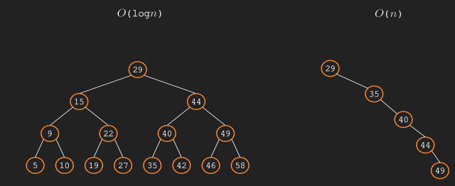

So what about the other one (right pic above)? This is what a tree with an O(n) complexity would look like, even though it looks more like a stick than a tree. It's technically a tree, and I hope you can guess why this is of O(n) complexity. Well, let's say we wanted to add the number 50 to this tree. We again start at the root, do one comparison, then move to the right. Compare again, move to the right once again and again until we reach the next available spot. Notice that with this type of tree we did five comparisons, but the tree has five nodes in total. If this was 1 million nodes, we would have to do 1 million comparisons, so the time would increase proportionally to the size of the tree. This is why this is O(n)complexity.

And what we see here are the extreme cases. One is perfectly balanced and the other one is basically a singly linked list. But most of the time when it comes to shape, binary search trees are somewhere in between. They might be skewed to one side or the other, or have branches that are either shallower or deeper. It all depends on the value of the root and the next nodes added afterwards

##### Time : Best - *O* (logn) | Worst - *O* (n)

##### Space : *O* (1)

### Contains

We want to write a function that takes a parameter, and then looks around the tree to see if it contains that value

So if we were to describe this as pseudocode, the logic will be like this.

1. Save the current root in a variable,
2. Start a while loop that will run until this variable ends up being none.
3. Inside the while loop, Check if the value you want to find is equal to the value inside the current node.
4. If it is, return true and be done with it. If it's not equal, check if it's smaller.
5. In this case, update the current variable to be its left child, and if it's larger, update it to be its right child.
6. Lastly, outside the while loop, return false if you didn't find the value you were looking for.

And that would be the process of searching for a value in a tree

```python
def contains(self, value):
    current_node = self.root # - Starts the search at the root node of the tree. self.root is assumed to be the top-most node of the tree.
    while current_node :# Loops as long as there is a node to check.If current_node becomes None,it means we’ve reached a leaf without finding the value.
        if value == current_node.value: # If the value matches the current_node value, it returns True, confirming that we found the value
            return True
        if value < current_node.value: # if the value is lesser than current node value, it switches the current to left node and the loop continues
            current_node = current_node.left # with the updated current_node
        else :
            current_node = current_node.right
    return False
```

1. Why we don’t use `.value` in `current_node = self.root`
- At this line, we’re not comparing anything yet — we’re just assigning a reference to the root node object.
- `self.root` is itself a Node object (with attributes like `value`,`left`,`right`).
- So `current_node` is meant to hold the whole node, not just the value.

Later, when we want to compare, we should use `current_node.value`.

That’s why `.value` isn’t used in the assignment. We want the node, not just its stored value.

2. Why we don’t check if left/right exists before moving
- The loop condition `while current_node` already ensures we only continue if the node exists.

Inside the loop:

- If `current_node.left` or `current_node.right` is `None`, then `current_node` becomes `None`.
- On the next iteration,`while current_node`fails, and the loop exits → `return False`.

👉 So we don’t need an explicit check like `if current_node.left is not None`. The loop condition handles it naturally.

#### Time And Space Complexity

When it comes to the complexity of this function, the best for time is O(logn) and the worst being O(n). For this space we have O(1). Everything is exactly the same as the insert method

##### Time : Best - *O* (logn) | Worst - *O* (n)

##### Space : *O* (1)

### Remove

Remove is quite complex and has a few scenarios to cover, hence we are splitting it into four sections, each of them covering a separate case.

In this section we will describe what remove is and what we want to achieve with it. We'll also write some code of locating the nodes involved in removing a value. In the next 3 sections, we will explain the different situations we might encounter when we want to remove a node.

Just like the remove method we did for the linked lists, we want it to delete a node based on a value we provide. But the issue is that the nodes in a tree can be of more than one type. The removed node can be the root. It can be a leaf. It can be a node that has one child. Or one that has two children. These are all different cases we need to consider

**But before we talk about how to remove a node, we first need to find it. Also, do we need to locate only the node we want to remove, or do we also need something else?**

Let's take below example. The `5` node. What is keeping this node part of the tree? The answer to that is the link.It has to `9` its parent node.If we cut that link, `5` and `8` will be removed from the list.So when we'll search for our node to remove. We also need to keep track of its parent, just like we did when removing from a singly linked list.

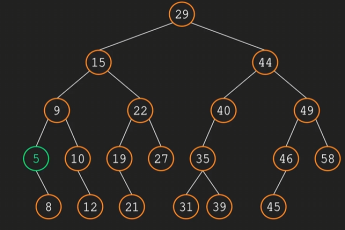

**Strategy for implementing Remove**

Let's write the code for the first part of the algorithm, locating the node we want to remove. And the way to do it would be like this.

1. We start with a current node variable that will initially be equal to the root of the tree.
2. We also want a second variable to keep track of the parent of the current node.
3. We then do a while loop and update both the parent and the current node variables until we either find the value we're looking for or until we reach the none value.
4. If current node will be none, it means that the value we're looking for is not in the tree and we can stop the program.
5. If we find our node, we need to check the number of children it has, and we can stop here for this section

**Setting up Building Blocks (Node) for Binary Search Tree**

```python
# Python class definitions for a Binary Search Tree (BST) and its nodes
# We define Node and BinarySearchTree classes because they provide the structure & functionality necessary to build &
# manipulate a binary search tree efficiently
# Node Represents a single element in the tree. Holds a value, and links to left and right children.
# Node Does not need a root because nodes are just building blocks.
class Node:
    def __init__(self, value):
        self.value = value # Stores the node's value
        self.left = None   # Left child (smaller values)
        self.right = None  # Right child (larger values)
# Without this class, there would be no way to create and manage individual nodes!
```

```python
# A binary search tree represents the entire tree structure and is a collection of nodes, and it needs a way to:
# a.Insert values efficiently b.Search for values c.Remove values while maintaining tree structure
class BinarySearchTree:
    def __init__(self):
        self.root = None
# All operations(insert,remove,search & traversal) will be performed on self.root and its children. Without this class, nodes
# wouldn’t be connected into a meaningful tree structure! 🌳
# Think of Node as bricks and BinarySearchTree as the blueprint that organizes them into a house🏠
```

So, we said that our method takes a value parameter based on which we'll remove the node. But this time we also want to add a start parameter, which will have a default value of none, and a parent one, which will also be none. The reason we have these two additional parameters is because we have a case where we will call remove starting from a certain node and not from the root. We'll see in forthcoming sections where this will be needed.

The next thing we will have to do is to create a current variable to store our node. But this time we don't want it to always be equal to the root. Since we now have this start parameter, we want our variable to be equal to it if it's provided. If it's not provided, we want it to be the root.

```python
# Below function is to first traverse thru the tree, find the location of the node to be removed & then check if it has any children (1 or more or none)
# to route to specific subfunctions
def remove(self, value, start=None, parent=None):
        current = start or self.root # If start is provided, use it; otherwise, start from the root.
# In Python, "or" returns the first truthy value or the last value if all are falsy.This behavior is known as short-circuiting,
# meaning Python stops evaluating once it finds a truthy value
        while current and current.value != value: #Loop until we find the node with the given value(current.value) or reach the end(current(node) = None)
            # if current becomes none , Python treats none as False and stops the loop.
            parent = current # Keep track of the parent node before moving left or right,so that, when we find the target node (current),
                             # we know who its parent is & we know how to adjust its parent's link.
            if value < current.value: # If the value is smaller, move to the left child (per Binary Tree logic)
                current = current.left
            else:
                current = current.right # If the value is higher, move to the right child
        if not current: # e.g if 4 < 5 but 5 has no left node then current =current.left will return None, which makes "if not current"condition as TRUE
            raise Exception("Item not in tree") # If we reach None, the value is not in the tree, so we raise an error.
# "not" operator checks if a value is False or None. Since current is a Node or None, a) If current exists (is not None) → The condition is False,
# and the program continues. b) If current doesn't exist (is None) → The condition is True, and we raise an exception.
        if not current.left and not current.right: # if current node has no left or right child
            return self._remove_node_no_children(current, parent) #If the node has no children, call _remove_node_no_children
        if current.left and current.right: # if current node has both left and right child
            return self._remove_node_two_children(current) # If the node has two children, call _remove_node_two_children
        return self._remove_node_one_child(current, parent)# If the node has one child, call _remove_node_one_child.
```

### Remove Node - No Children

**Logic :**

Let's consider below tree as an example and say we want to remove this node with the number `39`.Recall that removing `39` is done by cutting the connection with its parent, which is `35`.So how can we do that?

If what we implemented earlier is correct. After we locate the node we want to remove, we'll have two variables in memory the current node and its parent. So to remove the current node, we want to set the right child of the parent variable to be none. And how do we know it's the right child? Well, we can't know in advance. What we have to do is just check both children of the parent. If the left one is equal to the current node, we make it equal to none instead, and the same for the right child.

And there is also one special case of removing a leaf node. Can you guess it? It's the root when it's the only node in our tree. This is the only time when the root is also a leaf. In this case, our node to be removed does not have a parent, so we can't apply the same logic of checking the left and right children.

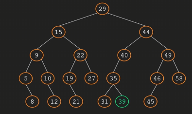

```python
# All remove child subfunctions are using "_" e.g _remove_node.. which indicates private helper fn, which keeps these internal fns hidden & prevents
# external users from accessing it. It also helps in better & clean code mgmt , breaks down complex tasks into smaller, reusable functions
def _remove_node_no_children(self, current, parent):
    # Removing the Root, if its the only node in the tree
    if current is self.root: # this is the only type of Remove when we can check if the root itself is the leaf (no children)
        self.root = None # If the node is the root, set self.root = None (tree becomes empty).
        return self
    # Checking which side of the parent is the current node
    if parent.left == current:
        parent.left = None # If the node is the left child of its parent, remove it by setting parent.left = None.
    else:
        parent.right = None # If the node is the right child of its parent, remove it by setting parent.right = None.
    return self
```

### Remove Node - One Child

**Scenario 1:**

In the tree we have here. There are a few nodes with only one child. One of them is `40`, which only has 35 as the left child. So what would removing `40` mean for the structure of the tree? In the previous case we discussed, we just made the parent point to none instead of our node. Here. We can't really do that because we'll lose all the nodes that branch out of `40`, like `35`, `31` and `39`.What we'll have to do is to point `44` to the child of `40`.This will both remove the desired node and keep in the tree the rest of the nodes that were on the branch.

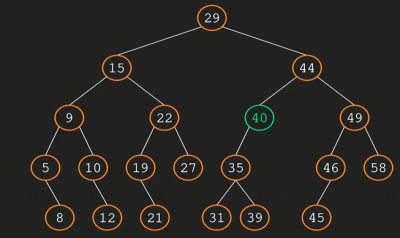

**Solution:**

We already saw that when we find the node we want to remove, we also keep track of its parent. So the first part of the logic is the same as the last method. We need to check both the left and the right attributes of the parent to see to which side is our node located. But after that, things are different because now we also need to know to which side of `40` is its child located. So we can point `44` to it. So we also need to do a similar check for the current node. If the left child of `40` exists and is not none, we must point the 44 to it. If the right child of 40 is not none, we need to point the parent to that one instead

**Scenario 2:**

If our tree looks like this and we want to remove the root `29` but it only has one child `44`, we can't apply the same logic since there is no parent.

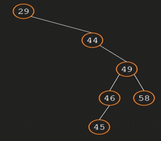

**Solution:**

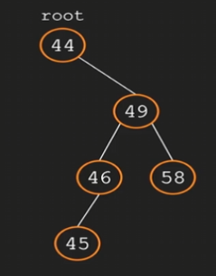